# Problem Set3: Least Square Regression

# Problem 1

Simple linear regression is to find $b_0$, $b_1$ such that they minimize the quadratic loss function(no regularization).
$$L(\beta_0, \beta_1) = \sum (y_i - \beta_0 - \beta_1 xi)^2$$
To find the global minimum, we take the partial derivatives with respect to each parameter of this multivariable($\mathbb{R}^2 \rightarrow \mathbb{R}$) function.
$$\frac{\partial L}{\partial\beta_0} = 2*(-1)*\sum_{i=1}^n(y_i - \beta_0 - \beta_1 x_i) = 0 \\
\frac{\partial L}{\partial\beta_1} = 2*\sum_{i=1}^n(-x_i)(y_i - \beta_0 - \beta_1 x_i) = 0$$
so $\sum_{i=1}^n(y_i - \beta_0 - \beta_1 x_i) = \frac{0}{-2} = 0$, therefore $\sum_{i=1}^n e_i = 0$

# Problem 2

1. Becuase a matrix’s cross product with its transpose is a symmetric matrix,

$$X^TX =
\begin{bmatrix}
30 & 0 & 0 \\
0 & 10 & 7 \\
0 & 7 & 15
\end{bmatrix}$$
n = 30(the inner product of the column with the constant term)
b.According to the property of matrix cross product,

$$X^TX =
\begin{bmatrix}
n & \sum X_i & \sum Z_i \\
0 & \sum X_i^2 & \sum X_i Z_i \\
0 & 7 & \sum Z_i^2
\end{bmatrix}$$
and $cor(x, z) = \frac{n\sum X_iZ_i - \sum X_i\sum Z_i}{\sqrt{n\sum X_i^2 - (\sum X_i)^2}\sqrt{n\sum Z_i^2 - (\sum Z_i)^2}}$

so

$$\begin{aligned}
cor(x, z) &= \frac{30 * 7 - 0 *0}{\sqrt{30 * 10 - 0^2} * \sqrt{30 * 15 - 0^2}} \\
&= \frac{210}{\sqrt{300} * \sqrt{450}} \\
&= 0.5715476
\end{aligned}$$
c.
$\bar y = - 2 + \bar x + 2 \bar z = - 2 + \frac{1}{n}(\sum X_i + 2\sum Z_i) = - 2 + 0 + 2*0 = -2$

4. Given, $R^2 = \frac{||\hat y||^2}{||y||^2} = \frac{\sum (\hat y - \bar y)^2}{\sum (\hat y - \bar y)^2 + RSS}$, To find $R^2$, we have to find $\sum (\hat y - \bar y)^2$

$$\begin{aligned}
\sum (\hat y - \bar y)^2 &= \sum (-2 + x_i + 2z_i - (-2))^2 \\
&= \sum (x_i + 2z_i)^2 \\
&= \sum (x_i^2 + 4z_i^2 + 4x_iz_i) \\
&= \sum x_i^2 + 4\sum z_i^2 + 4\sum x_iz_i \\
&= 10 + 4*15 + 4*7 \\
&= 98
\end{aligned}$$

# Problem 3

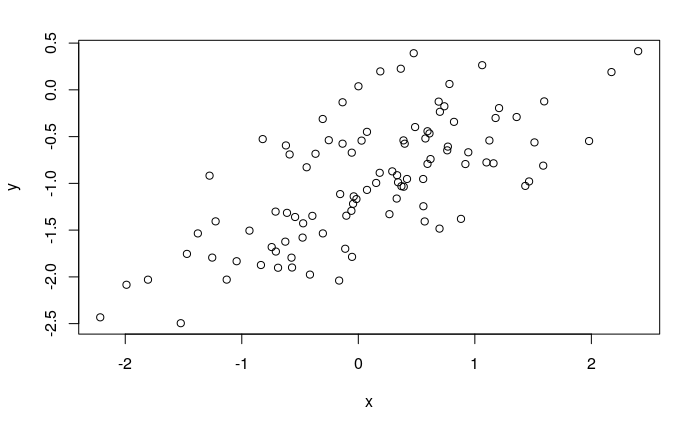

```r
set.seed(1)
#a
x <- rnorm(100)
#b
eps <- rnorm(100, mean = 0, sd = 0.5)
#c
y <- -1 + 0.5*x + eps
#d
plot(x, y)
```

```r
#e
reg <- lm(y~x)
summary(reg)
```

```
Call:
lm(formula = y ~ x)

Residuals:
     Min       1Q   Median       3Q      Max
-0.93842 -0.30688 -0.06975  0.26970  1.17309

Coefficients:
            Estimate Std. Error t value Pr(>|t|)
(Intercept) -1.01885    0.04849 -21.010  < 2e-16 ***
x            0.49947    0.05386   9.273 4.58e-15 ***
---
Signif. codes:  0 ‘***’ 0.001 ‘**’ 0.01 ‘*’ 0.05 ‘.’ 0.1 ‘ ’ 1

Residual standard error: 0.4814 on 98 degrees of freedom
Multiple R-squared:  0.4674,    Adjusted R-squared:  0.4619
F-statistic: 85.99 on 1 and 98 DF,  p-value: 4.583e-15
```

```r
#f
plot(x, y)
abline(reg, col = "blue")
```

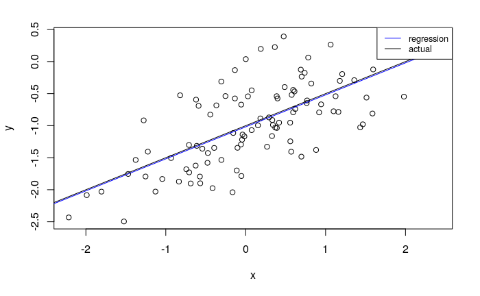

```r
abline(a=-1, b=0.5, col = "black")
legend("topright", c("regression", "actual"), col=c("blue", "black"), lty=1, cex=0.8)
```

```r
#g
reg2 <- lm(y ~ poly(x, 2, raw=T))
print("reg1 vs reg2, absolute error vs square error")
```

```
[1] "reg1 vs reg2, absolute error vs square error"
```

```r
print(paste(sum(abs(reg$residuals)), sum(abs(reg2$residuals))))
```

```
[1] "37.7109692989015 38.0552098547766"
```

```r
print(paste(sum(reg$residuals * reg$residuals), sum(reg2$residuals*reg2$residuals)))
```

```
[1] "22.7089022692233 22.257276711411"
```

Comment: d: the plot looks decently homoscedastic e: the estimates are very close g: the 2nd degree polynomial has a better(smaller) MSE but higher sum of absolute errors. In summary, the performance of 1degree and 2degree is difficult to tell.

### h

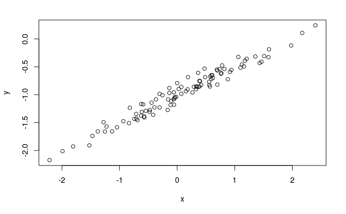

```r
set.seed(1)
#a
x <- rnorm(100)
#b
eps <- rnorm(100, mean = 0, sd = 0.1)
#c
y <- -1 + 0.5*x + eps
#d
plot(x, y)
```

```r
#e
reg <- lm(y~x)
summary(reg)
```

```
Call:
lm(formula = y ~ x)

Residuals:
     Min       1Q   Median       3Q      Max
-0.18768 -0.06138 -0.01395  0.05394  0.23462

Coefficients:
             Estimate Std. Error t value Pr(>|t|)
(Intercept) -1.003769   0.009699  -103.5   <2e-16 ***
x            0.499894   0.010773    46.4   <2e-16 ***
---
Signif. codes:  0 ‘***’ 0.001 ‘**’ 0.01 ‘*’ 0.05 ‘.’ 0.1 ‘ ’ 1

Residual standard error: 0.09628 on 98 degrees of freedom
Multiple R-squared:  0.9565,    Adjusted R-squared:  0.956
F-statistic:  2153 on 1 and 98 DF,  p-value: < 2.2e-16
```

```r
#f
plot(x, y)
abline(reg, col = "blue")
```

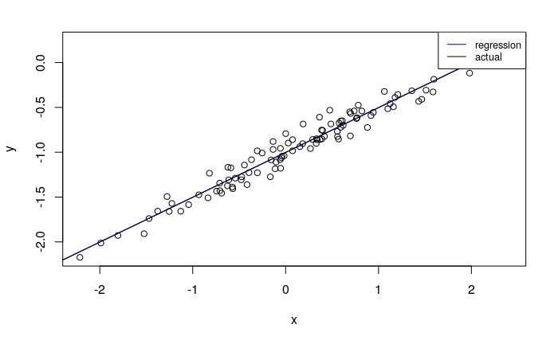

```r
abline(a=-1, b=0.5, col = "black")
legend("topright", c("regression", "actual"), col=c("blue", "black"), lty=1, cex=0.8)
```

Comment: g.The two lines almost overlap each other. When there is less noise, simple linear regression owns.

# i

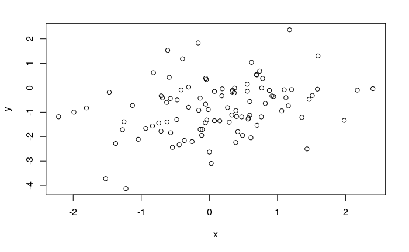

```r
#b
eps <- rnorm(100, mean = 0, sd = 1)
#c
y <- -1 + 0.5*x + eps
#d
plot(x, y)
```

```r
#e
reg <- lm(y~x)
summary(reg)
```

```
Call:
lm(formula = y ~ x)

Residuals:
     Min       1Q   Median       3Q      Max
-2.80747 -0.63372 -0.04862  0.62789  2.77755

Coefficients:
            Estimate Std. Error t value Pr(>|t|)
(Intercept)  -0.8527     0.1068  -7.985 2.73e-12 ***
x             0.3782     0.1186   3.189  0.00192 **
---
Signif. codes:  0 ‘***’ 0.001 ‘**’ 0.01 ‘*’ 0.05 ‘.’ 0.1 ‘ ’ 1

Residual standard error: 1.06 on 98 degrees of freedom
Multiple R-squared:  0.094, Adjusted R-squared:  0.08476
F-statistic: 10.17 on 1 and 98 DF,  p-value: 0.001919
```

```r
#f
plot(x, y)
abline(reg, col = "blue")
```

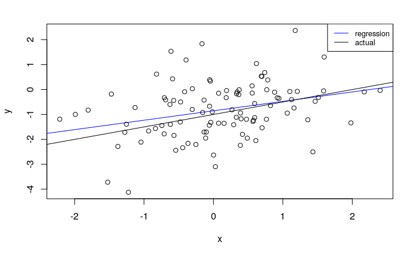

```r
abline(a=-1, b=0.5, col = "black")
#need to add legends, https://stat.ethz.ch/R-manual/R-devel/library/graphics/html/legend.html
#legend(legend="reg")
legend("topright", c("regression", "actual"), col=c("blue", "black"), lty=1, cex=0.8)
```

Comment: g. With more noise(can see from the graph), the regression line tilts wider away from the “true” process, however, it is still relatively close under this level of noise.

# Problem4

```r
#refer to the lab result
# ols fit using QR
ols_fit <- function(X, y) {
  # Computer an OLS fit for linear regression using QR, returning multiple aspects of the fit
  #
  #Args:
  # x: a matrix with 1s, and other predictors
  # y: the response variable
  #
  #Returns:
  # A list of information about the ols fit, with attributes
  #   coefficients: intercept, slope1, slope2 and etc.
  #   y_values: y
  #   fitted_values
  #   residuals: y_values - fitted_values
  #   n: number of observations
  #   q: number of parameters

  #using qr to computer cofficients
  qr <- qr(X)
  q <- qr.Q(qr)
  r <- qr.R(qr)
  b <- solve(r, t(q) %*% y)

  #fitted values and residuals
  y.hat <- crossprod(t(X), b)
  resi <- y - y.hat

  return(list(coefficients=b, y_values=y, fitted_values=y.hat, residuals=resi, n=length(y), q=ncol(X)))
}
```

### Testing 4

```r
fit <- ols_fit(cbind(1, mtcars$disp, mtcars$hp), mtcars$mpg)
names(fit)
```

```
[1] "coefficients"  "y_values"      "fitted_values" "residuals"     "n"             "q"
```

```r
fit$coefficients
```

```
            [,1]
[1,] 30.73590425
[2,] -0.03034628
[3,] -0.02484008
```

```r
summary(fit$fitted_values)
```

```
       V1
 Min.   :11.32
 1st Qu.:15.16
 Median :21.64
 Mean   :20.09
 3rd Qu.:24.70
 Max.   :27.15
```

```r
summary(fit$residuals)
```

```
       V1
 Min.   :-4.7945
 1st Qu.:-2.3036
 Median :-0.8246
 Mean   : 0.0000
 3rd Qu.: 1.8582
 Max.   : 6.9363
```

# Problem5

```r
R2 <- function(fit) {
  y.bar <- mean(fit$y_values)
  regss <- sum((fit$fitted_values - y.bar) * (fit$fitted_values - y.bar))
  tss <- sum((fit$y_values - y.bar) * (fit$y_values - y.bar))
  return(regss/tss)
}
RSE <- function(fix) {
  RSS <- sum(fit$residuals * fit$residuals)
  return(sqrt(RSS/(fit$n-fit$q)))
}
```

### Testing Problem5

```r
fit <- ols_fit(cbind(1, mtcars$disp, mtcars$hp), mtcars$mpg)
R2(fit)
```

```
[1] 0.7482402
```

```r
RSE(fit)
```

```
[1] 3.126601
```

# problem6

```r
cor(performance[,1]+rnorm(8, sd=0.01), 1:8)
```

```
[1] -0.08025937
```

As we add more features, we tend to overfit the model(reducing our errors) but RSE remains the same(the standard deviation of our errors). In other words, as we add more features, we are unable to narrow down the errors of our forecasts.

# problem7

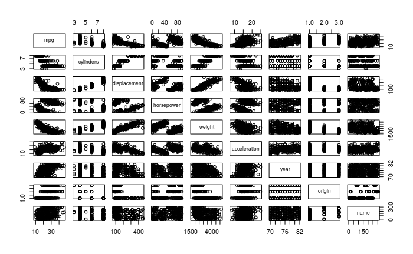

```r
summary(auto.reg)
```

```
Call:
lm(formula = mpg ~ ., data = auto.quan)

Residuals:
   Min     1Q Median     3Q    Max
-9.629 -2.034 -0.046  1.801 13.010

Coefficients:
               Estimate Std. Error t value Pr(>|t|)
(Intercept)  -2.128e+01  4.259e+00  -4.998 8.78e-07 ***
cylinders    -2.927e-01  3.382e-01  -0.865   0.3874
displacement  1.603e-02  7.284e-03   2.201   0.0283 *
horsepower    7.942e-03  6.809e-03   1.166   0.2442
weight       -6.870e-03  5.799e-04 -11.846  < 2e-16 ***
acceleration  1.539e-01  7.750e-02   1.986   0.0477 *
year          7.734e-01  4.939e-02  15.661  < 2e-16 ***
origin        1.346e+00  2.691e-01   5.004 8.52e-07 ***
---
Signif. codes:  0 ‘***’ 0.001 ‘**’ 0.01 ‘*’ 0.05 ‘.’ 0.1 ‘ ’ 1

Residual standard error: 3.331 on 389 degrees of freedom
Multiple R-squared:  0.822, Adjusted R-squared:  0.8188
F-statistic: 256.7 on 7 and 389 DF,  p-value: < 2.2e-16
```

there is a relationship btw the predictors and response because the adjusted Rsquare is pretty high and F-test is statistically significant.

displacement, weight, acceleration, year and origin are statistically significant predictors.

year’s coefficient suggests for each increase year(of production), the vehicle’s mpg increases by 0.7734.

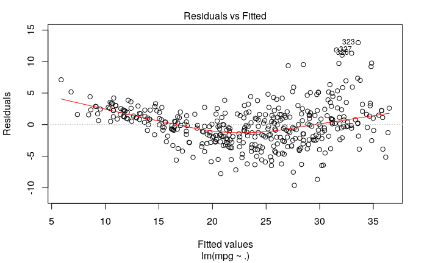

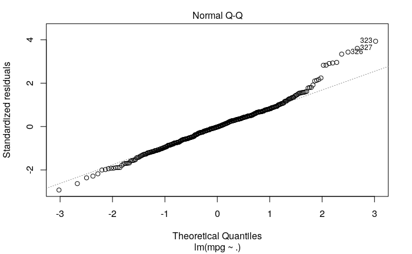

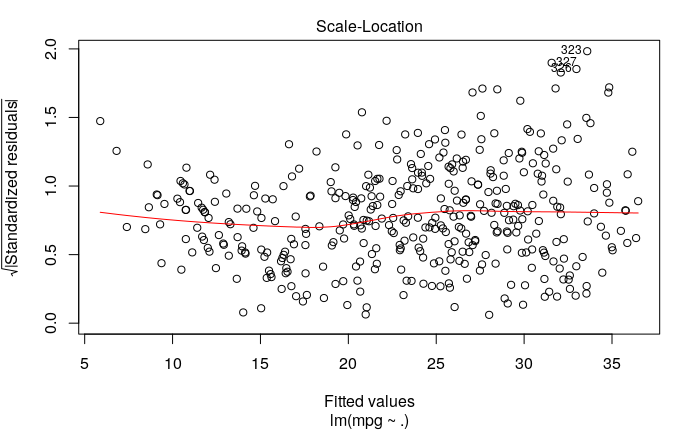

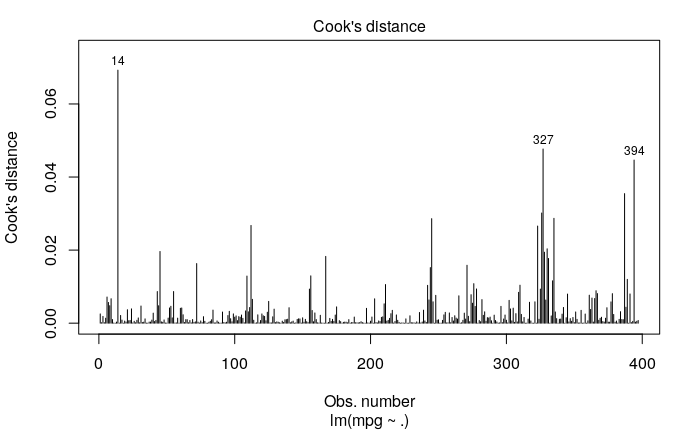

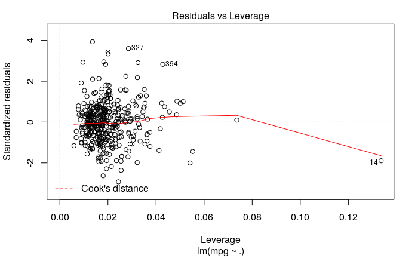

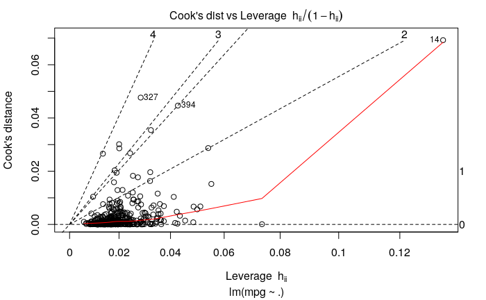

Comments: The residual plot suggests observation 323, 326, 327 have high (positive) residuals(and a few unlabeledp points). Among them(obs. 323, 326, 327), 327 and 394 has relatively high cook’s distance(influence on the parameters), along with obs. 14, with abnormally high cook’s distance and leverage.

Own Obersvations:  
High leverage points doesn’t ensure high influence on the model(but many of them do).

### e. modeling with interaction effect

```r
auto.reg.inter <- auto.reg.test <- lm(mpg~. + displacement*weight,
                   data = auto.quan
                   #%>%
                     #factorizing the cateogrical variables
                     #mutate(cylinders = factor(cylinders)) %>%
                     #mutate(origin = factor(origin))
                   )
summary(auto.reg.inter)
```

```
Call:
lm(formula = mpg ~ . + displacement * weight, data = auto.quan)

Residuals:
    Min      1Q  Median      3Q     Max
-9.8561 -1.8167 -0.0141  1.7027 12.1594

Coefficients:
                      Estimate Std. Error t value Pr(>|t|)
(Intercept)         -1.130e+01  3.948e+00  -2.863  0.00443 **
cylinders            2.463e-01  3.079e-01   0.800  0.42424
displacement        -7.153e-02  1.104e-02  -6.479  2.8e-10 ***
horsepower           2.114e-03  6.129e-03   0.345  0.73029
weight              -1.127e-02  6.854e-04 -16.437  < 2e-16 ***
acceleration         2.100e-01  6.966e-02   3.014  0.00275 **
year                 8.181e-01  4.448e-02  18.394  < 2e-16 ***
origin               4.428e-01  2.580e-01   1.716  0.08687 .
displacement:weight  2.212e-05  2.249e-06   9.833  < 2e-16 ***
---
Signif. codes:  0 ‘***’ 0.001 ‘**’ 0.01 ‘*’ 0.05 ‘.’ 0.1 ‘ ’ 1

Residual standard error: 2.984 on 388 degrees of freedom
Multiple R-squared:  0.8575,    Adjusted R-squared:  0.8546
F-statistic: 291.9 on 8 and 388 DF,  p-value: < 2.2e-16
```

Year, I choose displacement*weight. Things I find:  
using the “cateogrical” numerical variable(categorical variable that are numerically encoded) is kind of a mess. I have a 0.4 improvment in RSE and 0.04 improvement in adjusted R2.

### f. variable transformation

## First check the distribution of the variables

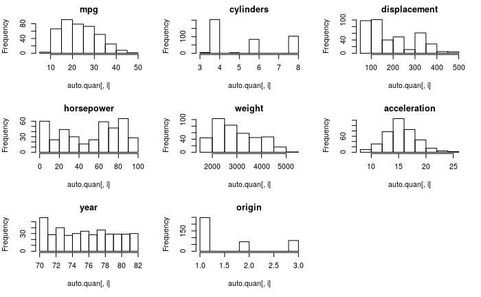

## best results from trying out new things

```r
summary(auto.reg.test)
```

```
Call:
lm(formula = mpg ~ ., data = auto.quan %>% select(-c(horsepower,
    displacement, acceleration)) %>% mutate(cylinders = factor(cylinders)) %>%
    mutate(mpg = log(mpg)) %>% mutate(origin = factor(origin)) %>%
    mutate(weight = log(weight)))

Residuals:
     Min       1Q   Median       3Q      Max
-0.35774 -0.06612  0.00116  0.06183  0.42835

Coefficients:
             Estimate Std. Error t value Pr(>|t|)
(Intercept)  6.655184   0.379617  17.531  < 2e-16 ***
cylinders4   0.270753   0.057755   4.688 3.83e-06 ***
cylinders5   0.353132   0.088252   4.001 7.54e-05 ***
cylinders6   0.206360   0.059956   3.442 0.000641 ***
cylinders8   0.180068   0.062750   2.870 0.004335 **
weight      -0.779648   0.045703 -17.059  < 2e-16 ***
year         0.031631   0.001665  18.992  < 2e-16 ***
origin2      0.037728   0.018444   2.046 0.041475 *
origin3      0.038381   0.018203   2.108 0.035629 *
---
Signif. codes:  0 ‘***’ 0.001 ‘**’ 0.01 ‘*’ 0.05 ‘.’ 0.1 ‘ ’ 1

Residual standard error: 0.1118 on 388 degrees of freedom
Multiple R-squared:  0.8941,    Adjusted R-squared:  0.8919
F-statistic: 409.3 on 8 and 388 DF,  p-value: < 2.2e-16
```

After few minutes of tweakings, I find that:

1. log(mpg) has better performance than log2(mpg), but log transformation helps in general since the distribution of mpg is right skewed.
2. factorizing categorical variables help in this case
3. agumenting old features may make some features less significant(may due to multicolinearity)
4. scaling a variable doesn’t really affect the performance. 5.RSE maybe misleading since log scale will reduce the scale of the error